# eda

## Iris Flower EDA: Exploring Species Classification

###### Author: Anatoly Lunev

###### Date: 2025-09-24

###### Problem Statement: Analyze sepal and petal measurements in the Iris dataset to uncover patterns and features that distinguish species, using Python, SQL, and visualizations.

###### Goal: Explore and visualize the Iris dataset to uncover patterns by species.

###### Skills practiced: Data cleaning, visualization, SQL querying, and insight summarization.

###### Tools: Python, Jupyter, Pandas, Matplotlib, Seaborn, Plotly, pandasql, Git.

#### Step 1. Setting Up the Environment in VS Code

- **VS Code extensions were installed**:
  - Python (by Microsoft)
  - Jupyter (for notebooks)
  - GitHub Pull Requests and Issues
  - SQLite
- **A new project folder was created**:

  ```
  mkdir iris_eda_project && cd iris_eda_project
  ```

- **Git was initialized**:

  ```
  git init
  ```

- **A virtual environment was created and activated**:

  ```
  python3 -m venv venv
  source venv/bin/activate
  ```

- **ipykernel was installed for Jupyter kernel support**:

  ```
  pip install ipykernel
  python3 -m ipykernel install --user --name=iris_eda --display-name="Iris EDA (venv)"
  ```

- **Core packages were installed**:

  ```
  pip install pandas pandasql numpy matplotlib seaborn plotly jupyter
  ```

- **Dependencies were saved to requirements.txt:

  ```
  pip freeze > requirements.txt
  ```

- **VS Code’s built-in Jupyter support was used by creating eda.ipynb**

#### Step 2. Fetching and Loading the Dataset

```python
# Necessary libraries were imported:
import pandas as pd  # For data manipulation
from pandasql import sqldf  # For SQL querying
import numpy as np   # For numerical operations
import matplotlib.pyplot as plt  # For plotting
import seaborn as sns  # For enhanced visualizations
import plotly.express as px  # For interactive visualizations
```

```python
# The Iris dataset was fetched from UCI (direct URL, no API needed) and loaded into a DataFrame:

try:
    url = "https://archive.ics.uci.edu/ml/machine-learning-databases/iris/iris.data"
    column_names = ['sepal_length', 'sepal_width', 'petal_length', 'petal_width', 'species']
    df = pd.read_csv(url, header=None, names=column_names)
except Exception as e:
    print(f"Error loading data: {e}")
```

```python
# A quick preview of the data was performed:
print(df.head())      # First 5 rows
print(df.info())      # Data types and non-null counts
print(df.describe())  # Basic statistics
```

```
   sepal_length  sepal_width  petal_length  petal_width      species
0           5.1          3.5           1.4          0.2  Iris-setosa
1           4.9          3.0           1.4          0.2  Iris-setosa
2           4.7          3.2           1.3          0.2  Iris-setosa
3           4.6          3.1           1.5          0.2  Iris-setosa
4           5.0          3.6           1.4          0.2  Iris-setosa
<class 'pandas.core.frame.DataFrame'>
RangeIndex: 150 entries, 0 to 149
Data columns (total 5 columns):
 #   Column        Non-Null Count  Dtype
---  ------        --------------  -----
 0   sepal_length  150 non-null    float64
 1   sepal_width   150 non-null    float64
 2   petal_length  150 non-null    float64
 3   petal_width   150 non-null    float64
 4   species       150 non-null    object
dtypes: float64(4), object(1)
memory usage: 6.0+ KB
None
       sepal_length  sepal_width  petal_length  petal_width
count    150.000000   150.000000    150.000000   150.000000
mean       5.843333     3.054000      3.758667     1.198667
std        0.828066     0.433594      1.764420     0.763161
min        4.300000     2.000000      1.000000     0.100000
25%        5.100000     2.800000      1.600000     0.300000
50%        5.800000     3.000000      4.350000     1.300000
75%        6.400000     3.300000      5.100000     1.800000
max        7.900000     4.400000      6.900000     2.500000
```

#### Step 3. Data Cleaning and Basic Exploration

```
Duplicates: 3
species
Iris-versicolor    50
Iris-virginica     49
Iris-setosa        48
Name: count, dtype: int64
```

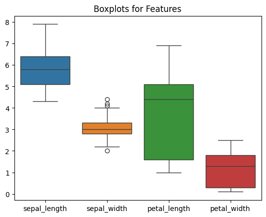

```python
# Duplicates and missing values were checked
print(f"Duplicates: {df.duplicated().sum()}")
df = df.drop_duplicates()

# The species column was converted to categorical type:
df['species'] = df['species'].astype('category')

# Basic exploration of nique species was performed:
print(df['species'].value_counts())

# Outliers were visualized using boxplots:
sns.boxplot(data=df.drop('species', axis=1))  # Visualizing distributions
plt.title('Boxplots for Features')
plt.show()

# Note: Iris has minimal outliers; if any, we can clip or ignore for simplicity
```

#### Step 4. Visualizations and Insights

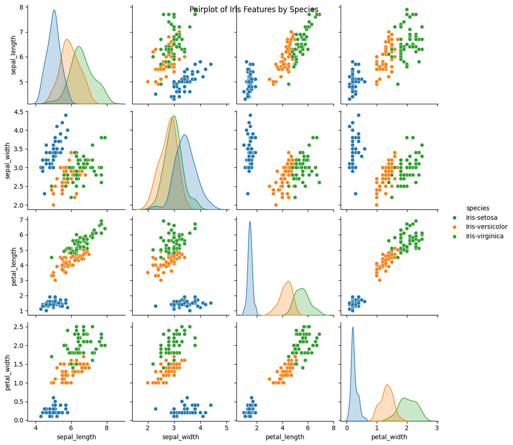

```python
# Relationships between features were visualized using pairplots:
sns.pairplot(df, hue='species')
plt.suptitle('Pairplot of Iris Features by Species')
plt.show()
```

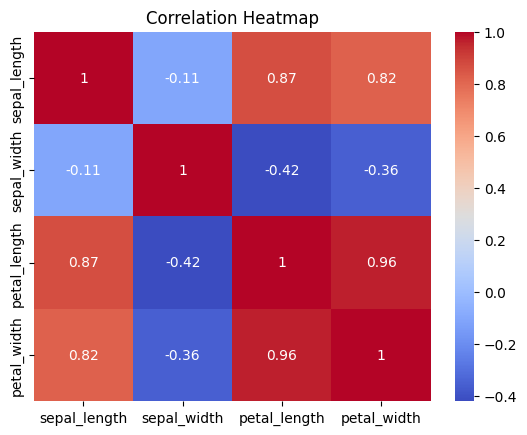

```python
# Feature correlations were visualized using a heatmap:
numeric_df = df.drop('species', axis=1)
corr = numeric_df.corr()
sns.heatmap(corr, annot=True, cmap='coolwarm')
plt.title('Correlation Heatmap')
plt.show()
```

```python
# Improved 3D Scatter Plot with Plotly
import plotly.express as px
fig = px.scatter_3d(df, x='petal_length', y='petal_width', z='sepal_length',
                    color='species', title='3D Scatter Plot of Iris Features',
                    size_max=10, opacity=0.7, width=800, height=600)
fig.show()
```

[output not shown]

##### Step 5. Adding SQL Querying for Practice

```python
# An example query was executed to calculate average measurements by species:
query = """
SELECT species, AVG(sepal_length) as avg_sepal_length, AVG(petal_length) as avg_petal_length
FROM df
GROUP BY species
"""
result = sqldf(query)
print(result)
```

```
           species  avg_sepal_length  avg_petal_length
0      Iris-setosa          5.010417          1.462500
1  Iris-versicolor          5.936000          4.260000
2   Iris-virginica          6.604082          5.561224
```

SQL Insights:

- Setosa averages: sepal_length ~5.01, petal_length ~1.46 (smallest).
- Versicolor: sepal_length ~5.94, petal_length ~4.26.
- Virginica: sepal_length ~6.60, petal_length ~5.56 (largest).
- Confirms petal_length as a key distinguisher.

##### Step 6. Wrapping Up and Preparing for GitHub

- EDA complete. Key findings: Petals distinguish Setosa; overlaps in others. Ready for GitHub!
- Changes were committed and pushed to GitHub using Terminal commands: `git add`, `git commit`, `git push`.
- Repository is available at: https://github.com/ketuser/iris-eda-project.